# Introduction

Chaque jour, plus de 80 000 vols commerciaux se déroulent à travers le monde, opérés par plusieurs centaines de compagnies aériennes. Pour tous les avions dont la masse au décollage excède 27 tonnes, une contrainte réglementaire impose aux compagnies que les données de tous les vols soient enregistrées et analysées systématiquement à des fins d’amélioration de la sécurité des vols. Le Flight Data Monitoring est la pratique des compagnies aériennes qui consiste à détecter et hiérarchiser des déviations par rapport à des standards fixés par les constructeurs d'avions, les autorités de l'aviation civile des pays ou même les compagnies elle-même. La détection des déviations, autrement appelés évènements, permet d'alimenter une base de données qui permet à la compagnie d'identifier et de surveiller les risques inhérents à ces opérations. Cette analyse est en première ligne pour améliorer la sécurité du transport aérien.

Ce TP a pour but de vous faire manipuler des données aéronautiques réelles, données fournies par le groupe Safran. Il se déroule en deux parties. Dans la première partie, vous effectuerez du traitement de données brutes, c'est-à-dire les prétraitements et visualisations nécessaires afin d'effectuer une analyse des données. Dans la seconde partie vous effectuerez des analyses plus haut niveau en repartant d'un jeu de données propres.

# Partie 1 : traitement des données

## 1.1 Chargement des données

Chargez les données dans la structure proposée grâce au code fourni. La définition des variables disponible est donnée ici :

- T : temps (s)
- LATP_1 : Latitude (°)
- LONP_1 : Longitude (°)
- RALT1 : Radio Altitude, capteur 1 (m)
- RALT2 : Radio Altitude, capteur 2 (m)
- RALT3 : Radio Altitude, capteur 3 (m)
- ALT_STD : Altitude relative (m)
- HEAD : head (°)
- PITCH : pitch (°)
- ROLL : roll (°)
- MACH : nombre de Mach (Mach)
- IAS : Indicative Air Speed (m/s)
- N11 : vitesse N1 du premier moteur (% de tr/min)
- N21 : vitesse N2 du premier moteur (% de tr/min)
- N12 : vitesse N1 du second moteur (% de tr/min)
- N22 : vitesse N2 du second moteur (% de tr/min)
- AIR_GROUND : status dans les airs / en l'air (booléen)
- AP_ENGAGED : Autopilote actif (booléen)
- AP_OFF : Autopilote inactif (booléen)

```python
import csv
import numpy as np
from os import listdir
from os.path import isfile, join

#fonction de chargement des données
def load_data_from_directory(DATA_PATH):
    files_list = [f for f in listdir(DATA_PATH) if isfile(join(DATA_PATH, f))]
    Fe = 1
    flight_list = list()
    max_flight = 390
    for ind_file,afile in enumerate(files_list):
        flight_list_struct = {}
        if np.mod(ind_file,max_flight/10)==0:
            print(np.round(float(ind_file)/float(max_flight)*100),'%')
        if ind_file <max_flight:
            variables_names = list()
            data_dictionary = {}
            mask_dictionary = {}
            file=open(join(DATA_PATH,afile), 'r')
            csv_file=csv.reader(file,delimiter=',')
            for ind_row,row in enumerate(csv_file):
                if ind_row==0:
                    variables_names = row
                    for id_var,var_name in enumerate(variables_names):
                        data_dictionary[var_name]=list()
                        mask_dictionary[var_name]=list()
                else:
                    for id_var,var_name in enumerate(variables_names):
                        try:
                            a = row[id_var]
                            data_dictionary[var_name].append(float(a))
                            mask_dictionary[var_name].append(1)
                        except:
                            if a=='':
                                data_dictionary[var_name].append(-1)
                            else:
                                data_dictionary[var_name].append(a)
                            mask_dictionary[var_name].append(0)
            for id_var,var_name in enumerate(variables_names):
                data_dictionary[var_name]=np.array(data_dictionary[var_name])
                mask_dictionary[var_name]=np.array(mask_dictionary[var_name],dtype=bool)

            flight_list_struct['DATA']=data_dictionary
            flight_list_struct['MASK']=mask_dictionary
            file.close()
        else:
            break
        flight_list.append(flight_list_struct)
    print('data loaded')
    return flight_list,variables_names

DATA_PATH = "/safran/TP_part1/"
flight_list,variables_names = load_data_from_directory(DATA_PATH)
max_flight = len(flight_list)
```

```
0.0 %
10.0 %
20.0 %
30.0 %
40.0 %
50.0 %
60.0 %
70.0 %
80.0 %
90.0 %
100.0 %
data loaded
```

La structure de données est une liste des vols, qui contient l'ensemble des données nécessaires pour le TP. Chaque élément de la liste est divisé en deux parties : une partie 'DATA', qui contient un dictionnaire, pour lequel chaque clef est un vecteur de valeurs, et une partie 'MASK', qui contient le même dictionnaire mais la donnée attachée à chaque clef est un vecteur de booléen qui indique si la valeur est correcte ou non. Ainsi

```python
print(flight_list[0]['DATA']['N22'])
```

```
[ 60.63  60.63  60.63 ...,  58.75  58.75  58.75]
```

contient le vecteur de toutes les valeurs du paramètre N22, pour le vol 0. De même,

```python
print(flight_list[0]['MASK']['N22'])
```

```
[ True  True  True ...,  True  True  True]
```

contient le vecteur de booléens qui correspond à la validité du paramètre. Ce booléen permettra par la suite d'invalider les valeurs aberrantes lors des phases de filtrage. Ci-dessous l'ensemble des variables.

```python
print(flight_list[0]['DATA'].keys())
```

```
dict_keys(['MACH', 'RALT1', 'N12', 'AP_OFF', 'N22', 'LATP_1', 'N21', 'LONP_1', 'IAS', 'AP_ENGAGED', 'AIR_GROUND', 'T', 'ROLL', 'N11', 'ALT_STD', 'PITCH', 'RALT2', 'RALT3', 'HEAD'])
```

## 1.2 Visualisation

Afin d'effectuer des opérations de surveillance des vols, il est nécessaire de nettoyer les données. Pour bien commencer, il est important de visualiser les données qui sont disponibles, afin de comprendre au mieux leur nature et les problèmes qui leur sont associés (bruit, spécificités mathématiques, échelles, valeurs caractéristiques et autres). Affichez, pour un vol, un exemple de visualisation de chaque variable disponible.

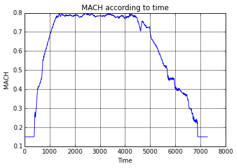

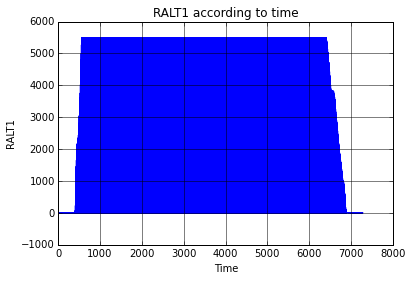

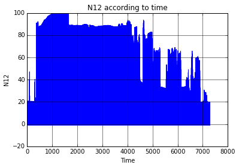

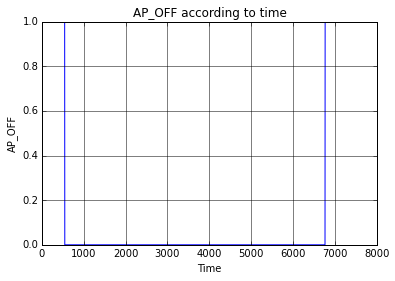

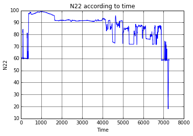

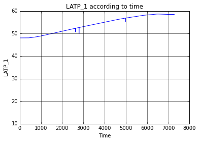

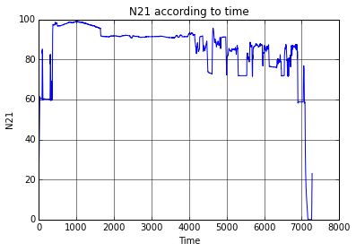

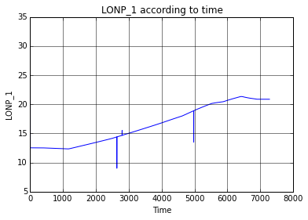

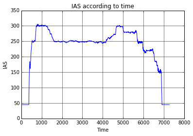

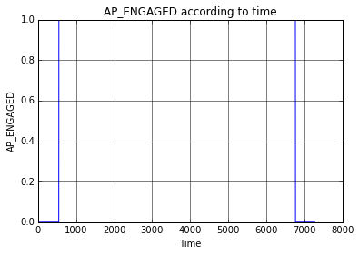

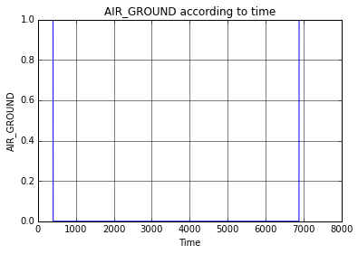

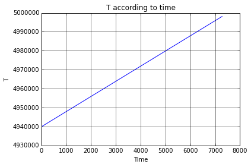

[7 more figures not shown]

```python
%matplotlib inline
import matplotlib
import matplotlib.pyplot as plt
#... à compléter ... #

for keys in flight_list[0]['DATA'].keys():
    plt.xlabel("Time")
    plt.ylabel(keys)
    plt.title(keys + ' according to time')
    plt.grid(True,which="both",ls="-")
    plt.plot(flight_list[0]['DATA'][keys])
    plt.show()
```

S'il est intéressant de voir les variables pour un vol donné, il est plus informatif de visualiser l'ensemble des valeurs pour tous les vols afin de comprendre quels sont les valeurs significatives/normales et quelles sont les celles qui sont plus anecdotiques/anormales. Pour la variable N21, affichez l'ensemble des vols sur une même figure. Proposez une visualisation permettant de bien faire la différence entre valeurs courantes et valeurs atypiques.

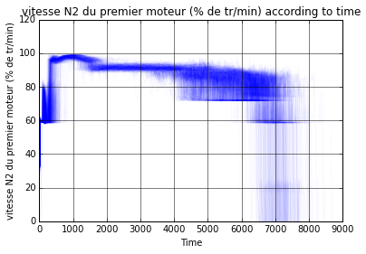

```python
for flight in range (len(flight_list)):
    plt.xlabel("Time")
    plt.ylabel('vitesse N2 du premier moteur (% de tr/min)')
    plt.title('vitesse N2 du premier moteur (% de tr/min) according to time')
    plt.grid(True,which="both",ls="-")
    plt.plot(flight_list[flight]['DATA']['N21'],'b', alpha=0.02)
plt.show()
```

Certaines variables doivent être analysées conjointement, sans quoi l'information tirée de l'analyse sera fortement incomplète. En particulier, affichez l'ensemble des trajectoires (latitude, longitude) à partir des différentes variables qui sont disponibles. Que constatez vous ?

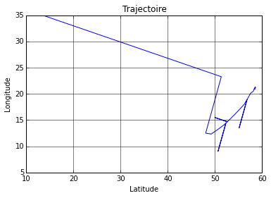

```python
plt.xlabel("Latitude")
plt.ylabel('Longitude')
plt.title('Trajectoire')
plt.grid(True,which="both",ls="-")
plt.plot(flight_list[0]['DATA']['LATP_1'],flight_list[0]['DATA']['LONP_1'],'b')
plt.show()
```

This is the trajectorty of the first flight.

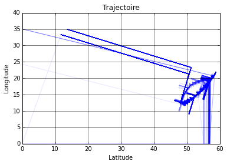

```python
for flight in range (len(flight_list)):
    plt.xlabel("Latitude")
    plt.ylabel('Longitude')
    plt.title('Trajectoire')
    plt.grid(True,which="both",ls="-")
    plt.plot(flight_list[flight]['DATA']['LATP_1'],flight_list[flight]['DATA']['LONP_1'],'b',alpha=0.1)
plt.show()
```

This is the entire set of trajectories and we can see that some trajectories prevail.

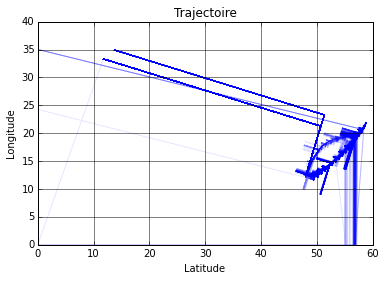

```python
for flight in range (len(flight_list)):
    plt.xlabel("Latitude")
    plt.ylabel('Longitude')
    plt.title('Trajectoire')
    plt.grid(True,which="both",ls="-")
    if flight_list[flight]['MASK']['LATP_1'].all() and  flight_list[flight]['MASK']['LONP_1'].all() :
        plt.plot(flight_list[flight]['DATA']['LATP_1'],flight_list[flight]['DATA']['LONP_1'],'b',alpha=0.1)
plt.show()
```

We tested the data so that we only plot the correct flights but it seems that there are no differences between the two graphs.

On rappelle que le but est de comprendre la nature et les problèmes intrinsèques des différentes données. D'après les différentes visualisations que vous avez pu faire, quelles sont, selon vous, les variables nécessitant un traitement? Pour chacune de ces variables, donnez le ou les traitements qui vous paraissent nécessaires avant d'effectuez des analyses. Certaines variables ont-elles déjà subit un traitement ?

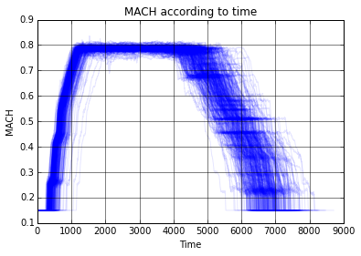

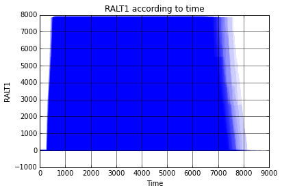

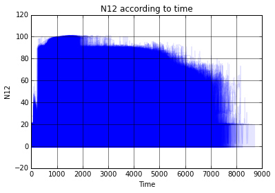

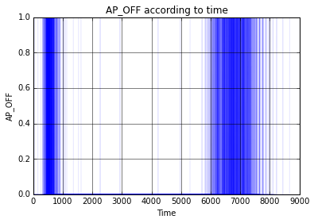

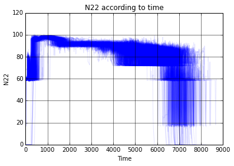

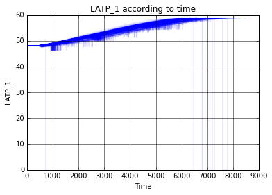

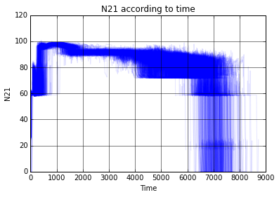

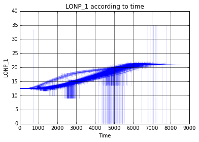

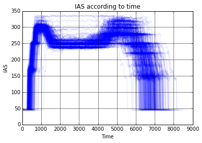

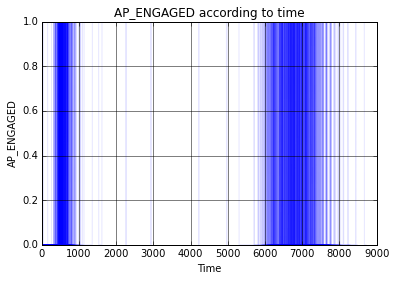

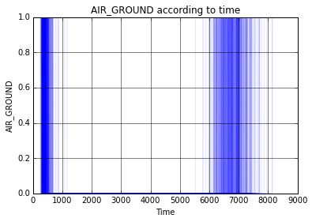

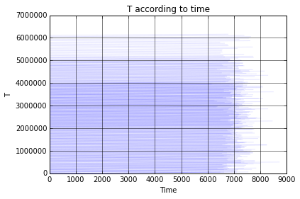

[7 more figures not shown]

```python
for keys in flight_list[0]['DATA'].keys():
    for flight in range (len(flight_list)):
        plt.xlabel("Time")
        plt.ylabel(keys)
        plt.title(keys + ' according to time')
        plt.grid(True,which="both",ls="-")
        plt.plot(flight_list[flight]['DATA'][keys],'b',alpha=0.1)
    plt.show()
```

After checking the MASK for every trajectories, there is still some of them which are irrelevant. They should all have the same trajectory but some flights seem to follow the longitude 0 until the end which seems strange. The captors might be defficient.

## 1.3 Traitements

La partie traitement est essentielle, afin de séparer les erreurs dues à la mesure et l'acquisition des variable de celles dues au phénomène qui nous intéresse.

Lorsque l'information est disponible, il peut être intéressant de fusionner différents capteurs mesurant une même variable. A partir des trois canaux RALT1, RALT2 et RALT3, créez une variable RALT_fus qui contiendra une fusion intelligente des trois canaux. Affichez un exemple avant/après.

```python
for flight in range(len(flight_list)):
    mean=[]
    for sum in range(len(flight_list[flight]['DATA']['RALT1'])) :
        mean.append((flight_list[flight]['DATA']['RALT1'][sum]+flight_list[flight]['DATA']['RALT2'][sum]+flight_list[flight]['DATA']['RALT3'][sum])/3)
    flight_list[flight]['DATA']['RALT_fus']=mean
```

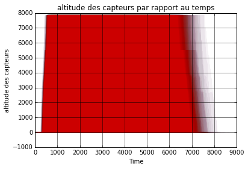

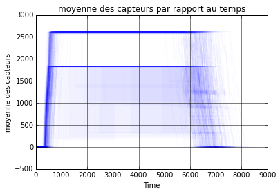

```python
for flight in range (len(flight_list)):
    plt.plot(flight_list[flight]['DATA']['RALT1'],'b', alpha=0.02)

for flight in range (len(flight_list)):
    plt.plot(flight_list[flight]['DATA']['RALT2'],'g', alpha=0.02)
for flight in range (len(flight_list)):
    plt.xlabel("Time")
    plt.ylabel('altitude des capteurs')
    plt.title('altitude des capteurs par rapport au temps')
    plt.grid(True,which="both",ls="-")
    plt.plot(flight_list[flight]['DATA']['RALT3'],'r', alpha=0.02)
plt.show()
for flight in range (len(flight_list)):
    plt.xlabel("Time")
    plt.ylabel('moyenne des capteurs')
    plt.title('moyenne des capteurs par rapport au temps')
    plt.grid(True,which="both",ls="-")
    plt.plot(flight_list[flight]['DATA']['RALT_fus'],'b', alpha=0.02)
plt.show()
```

There are two lines but we will assume that the highest one is predominant. It is way less noisy than the previous data.

Filtrez les valeurs abberrantes des données. En particulier, affichez les trajectoires avant/après filtrage.

Les angles sont des variables particulières car mathématiquement cycliques. Recalez les différents angles (si nécessaire) afin de ne plus avoir de discontinuités artificielles. Affichez les angles avant/après correction.

# Partie 2 : analyse

Nous abordons maintenant l'analyse sur les variables à proprement parler. Dans cette partie, les variables ont déjà été corrigées par des algorithmes existants, cependant vous pouvez avoir besoin des algorithmes précédemment développés. Vous avez à votre disposition :

- T : temps (s)
- LATPC : Latitude corrigée (°)
- LONPC : Longitude corrigée (°)
- RALTC : Radio Altitude corrigée (m)
- ALT_STDC : Altitude relative corrigée (m)
- HEAD_TRUE : head corrigé (°)
- PITCH_C : pitch corrigé (°)
- ROLL_C : roll corrigé (°)
- MACH_C : nombre de Mach corrigé (Mach)
- IAS_C : Indicative Air Speed corrigée (m/s)
- N11 : vitesse N1 du premier moteur (% tr/min)
- N21 : vitesse N2 du premier moteur (% tr/min)
- N12 : vitesse N1 du second moteur (% tr/min)
- N22 : vitesse N2 du second moteur (% tr/min)
- AIR_GROUND : status dans les airs / en l'air (booléen)
- AP_ENGAGED : Autopilote actif (booléen)
- AP_OFF : Autopilote inactif (booléen)

```python
DATA_PATH = "/safran/TP_part2/"
flight_list, variables_names = load_data_from_directory(DATA_PATH)
```

```
0.0 %
10.0 %
20.0 %
30.0 %
40.0 %
50.0 %
60.0 %
70.0 %
80.0 %
90.0 %
100.0 %
data loaded
```

## 2.1 Détection de phases de vol

Afin de bien comprendre les différents événements qui peuvent arriver, il est nécessaire de comprendre dans quelle phase de vol se situe l'avion. En effet, un événement qui pourrait être considéré comme normal dans une phase ne l'est pas toujours dans une autre. Détectez l'instant du décollage (Take off time). Mettez en évidence la phase en affichant la trajectoire verticale dans la minute qui précède et les 5 minutes qui suivent.

```python
print(flight_list[0]['DATA']['AIR_GROUND'][0])
```

```
1.0
```

```python
takeoff=[]
touchdown=[]
for flight in range(len(flight_list)):
    sum=0
    while (flight_list[flight]['DATA']['AIR_GROUND'][sum]==1) :
        sum+=1
    takeoff.append(flight_list[flight]['DATA']['T'][sum])
    while (flight_list[flight]['DATA']['AIR_GROUND'][sum]==0) :
        sum+=1
    touchdown.append(flight_list[flight]['DATA']['T'][sum])
```

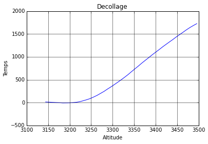

```
[14.0, 10.0, 5.0, 1.0, -2.0, -8.0, -7.0, -6.0, 0.0, 7.0, 20.0, 41.0, 63.0, 88.0, 122.0, 158.0, 201.0, 244.0, 295.0, 342.0, 393.0, 445.0, 498.0, 554.0, 612.0, 676.0, 738.0, 799.0, 863.0, 923.0, 982.0, 1043.0, 1100.0, 1156.0, 1215.0, 1270.0, 1324.0, 1377.0, 1434.0, 1486.0, 1538.0, 1592.0, 1641.0, 1685…
```

```python
decollage=[]
time=[]
for count in range (len(flight_list[0]['DATA']['T'])):
    if takeoff[0]-60<flight_list[0]['DATA']['T'][count] and takeoff[0]+300>flight_list[0]['DATA']['T'][count] :
        decollage.append(flight_list[0]['DATA']['ALT_STDC'][count])
        time.append(flight_list[0]['DATA']['T'][count]-flight_list[0]['DATA']['T'][0])

plt.xlabel("Altitude")
plt.ylabel('Temps')
plt.title('Decollage')
plt.grid(True,which="both",ls="-")
plt.plot(time,decollage,'b')
plt.show()

print(decollage)
```

De même, détectez l'instant où l'avion touche le sol (Touch_down_time). Mettez en évidence la phase en affichant la trajectoire verticale dans les 5 minutes qui précède et la minute qui suit.

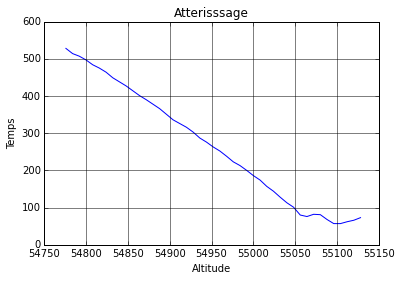

```python
atterissage=[]
time=[]
for count in range (len(flight_list[0]['DATA']['T'])):
    if touchdown[0]-300<flight_list[0]['DATA']['T'][count] and touchdown[0]+60>flight_list[0]['DATA']['T'][count] :
        atterissage.append(flight_list[0]['DATA']['ALT_STDC'][count])
        time.append(flight_list[0]['DATA']['T'][count]-flight_list[0]['DATA']['T'][0])

plt.xlabel("Altitude")
plt.ylabel('Temps')
plt.title('Atterisssage')
plt.grid(True,which="both",ls="-")
plt.plot(time,atterissage,'b')
plt.show()
```

Détectez le moment où l'avion termine sa montée (top of climb). Tracez la trajectoire verticale, d'une minute avant le décollage jusqu'à cinq minutes après le top of climb. Pour information, on considère qu'un avion est :

- en phase de montée si son altitude augmente de 30m pendant une seconde pendant 20 secondes
- en phase stable si son altitude ne varie pas de plus de 30m pendant 5 minutes
- en phase de descente si son altitude diminue de 30m pendant une seconde pendant 20 secondes

```python
for count in range ( len(flight_list[0]['DATA']['T'])):
    test=[]
    countbis=count
    if (flight_list[0]['DATA']['T'][count]>takeoff[0] and flight_list[0]['DATA']['T'][count]<touchdown[0]):
        while flight_list[0]['DATA']['T'][countbis]-flight_list[0]['DATA']['T'][count]<300 :
            test.append(flight_list[0]['DATA']['ALT_STDC'][countbis])
            countbis+=1
        if (max(test)-min(test)<=30):
            topclimb=flight_list[0]['DATA']['T'][count]
            break
print(topclimb,takeoff[0],touchdown[0])
```

```
4952969.0 4943073.0 4994945.0
```

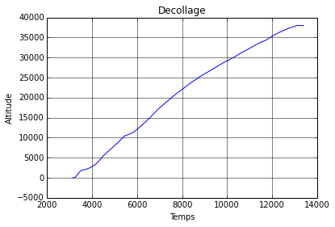

```python
ascension=[]
time=[]
for count in range (len(flight_list[0]['DATA']['T'])):
    if takeoff[0]-60<flight_list[0]['DATA']['T'][count] and topclimb+300>flight_list[0]['DATA']['T'][count] :
        ascension.append(flight_list[0]['DATA']['ALT_STDC'][count])
        time.append(flight_list[0]['DATA']['T'][count]-flight_list[0]['DATA']['T'][0])

plt.xlabel("Temps")
plt.ylabel('Altitude')
plt.title('Decollage')
plt.grid(True,which="both",ls="-")
plt.plot(time,ascension,'b')
plt.show()
```

De même pour le moment où l'avion entame sa première descente (top of descent).

```python
for count in range ( len(flight_list[0]['DATA']['T'])):
    test=[]
    countbis=count
    if (flight_list[0]['DATA']['T'][count]>topclimb and flight_list[0]['DATA']['T'][count]<touchdown[0]):
        while flight_list[0]['DATA']['T'][countbis]-flight_list[0]['DATA']['T'][count]<300 :
            test.append(flight_list[0]['DATA']['ALT_STDC'][countbis])
            countbis+=1
        if (max(test)-min(test)>30):
            topdesc=flight_list[0]['DATA']['T'][count]
            break
print(topdesc,takeoff[0],touchdown[0])
```

```
4972793.0 4943073.0 4994945.0
```

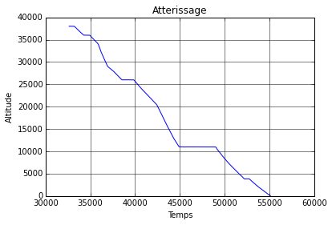

```python
descente=[]
time=[]
for count in range (len(flight_list[0]['DATA']['T'])):
    if topdesc-300<flight_list[0]['DATA']['T'][count] and touchdown[0]+60>flight_list[0]['DATA']['T'][count] :
        descente.append(flight_list[0]['DATA']['ALT_STDC'][count])
        time.append(flight_list[0]['DATA']['T'][count]-flight_list[0]['DATA']['T'][0])

plt.xlabel("Temps")
plt.ylabel('Altitude')
plt.title('Atterissage')
plt.grid(True,which="both",ls="-")
plt.plot(time,descente,'b')
plt.show()
```

We have decided to consider the moment 'top of the descent' as the timing for which the plane leaves the altitude of the stable phasis.

## 2.2 Détection de procédure d'attente

La procédure d'attente se passe lorsque l'avion ne se pose pas directement en arrivant, mais effectue une ou plusieurs boucle avant d'atterrir. Détectez les cas d'attente.

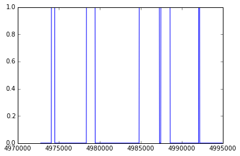

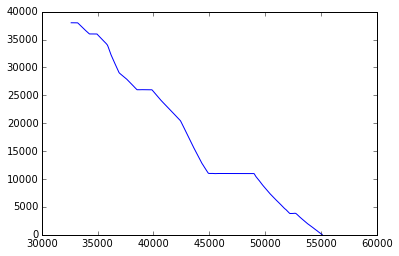

```python
attente=[]
timeatt=[]
for count in range ( len(flight_list[0]['DATA']['T'])):
    test=[]
    countbis=count
    if (flight_list[0]['DATA']['T'][count]>topdesc and flight_list[0]['DATA']['T'][count]<touchdown[0]):
        while flight_list[0]['DATA']['T'][countbis]-flight_list[0]['DATA']['T'][count]<300 :
            test.append(flight_list[0]['DATA']['ALT_STDC'][countbis])
            countbis+=1
        timeatt.append(flight_list[0]['DATA']['T'][count])
        if (max(test)-min(test)<=30):
            attente.append(1)

        else :
            attente.append(0)

plt.plot(timeatt,attente,'b')
plt.show()
plt.plot(time,descente,'b')
plt.show()
```

Le code suivant va detecter les phases d'attente avant la phase d'atterrissage.

## 2.3 Détermination des aéroports de départ et d'arrivée

Retrouvez l'aéroport de départ et l'aéroport d'arrivé, sachant que les données de trajectoires ont été modifiées par une translation et une rotation.

```python
DATA_PATH = "/safran/airports/"
airport_list, variables_names = load_data_from_directory(DATA_PATH)
```

```
0.0 %
data loaded
```

```python
print(airport_list[0]['DATA'].keys())
```

```
dict_keys(['5282', 'U', '1', '145.391881', 'AYGA', 'Goroka', '10', 'Papua New Guinea', 'Pacific/Port_Moresby', '-6.081689', 'GKA'])
```

Thanks to the Internet, we can calculate the distance between two points using only the latitude and the longitude. Using this method, we only need to calculate sin(a)sin(b)-cos(a)cos(b)cos(c-d) where a = latA b = latB c = lonA d = lonB We would have done this calculation for the position at the departure and the position at the arrival and then we would have looked for two airports in the airports data with the same result (which would mean that the distance between the arrival and the departure is the distance between the two airports). However, we didn't succeed in importing the data. We could have done it by adding a header in the original file but we don't think that it is allowed.

## 2.4 Procédures d'arrivée

Effectuez un clustering automatique des différentes approches possible pour un avion, puis affichez les en couleur.